# MCMCtreeR

Mark Puttick

marknputtick@gmail.com

University of Bath

20 May 2019

This is a guide for the R program [MCMCtreeR](https://github.com/PuttickMacroevolution).

MCMCtreeR contains functions to set up analyses in the [MCMCtree](http://abacus.gene.ucl.ac.uk/software/paml.html) program. The functions here help users choose the best parameters to reflect age information for prior age distributions, visualise time priors, and produce output files ready to be used in **MCMCtree**. A seperate [vignette](https://github.com/PuttickMacroevolution/MCMCtreeR/blob/master/vignettes/MCMCtree_plot_pdf.pdf) is available to explain the plotting options for timescaled trees in MCMCtreeR.

[MCMCtree](http://abacus.gene.ucl.ac.uk/software/paml.html) is a Bayesian program in the software PAML that estimates divergence times on fixed topologies using molecular data, developed by Ziheng Yang. The program requires various inputs from the user: a phylogeny, molecular sequence alignment, and selected model parameters. This guide does not include details about which time and other priors are most appropriate for the data, etc., so please see the [MCMCtree manual](https://github.com/PuttickMacroevolution/MCMCtreeR/blob/master/pamlDOC.pdf) for more information.

# Installation

```r
if (!any(rownames(installed.packages()) == "MCMCtreeR")) install.packages("MCMCtreeR")
library(MCMCtreeR, quietly = TRUE, warn.conflicts = FALSE)
```

The examples here use a phylogeny of apes and associated age information. These data are a phylogeny of apes `apeTree`, the minimum ages for internal nodes `minimumTimes`, maximum ages for internal nodes `maximumTimes`, and the tip labels descending from each node `monophyleticGroups`. These example data can be substituted for other data.

```r
data(apeData)
attach(apeData)
names(apeData)
```

```
## [1] "minimumTimes"       "maximumTimes"       "monophyleticGroups"
## [4] "apeTree"
```

```r
minimumTimes
```

```
##   nodeOne   nodeTwo nodeThree  nodeFour
##       1.5       0.6       0.8       1.3
```

```r
maximumTimes
```

```
##   nodeOne   nodeTwo nodeThree  nodeFour
##       3.0       1.2       1.2       2.0
```

```r
monophyleticGroups
```

```
## [[1]]
## [1] "human"      "chimpanzee" "bonobo"     "gorilla"    "sumatran"
## [6] "orangutan"  "gibbon"
##
## [[2]]
## [1] "human"      "chimpanzee" "bonobo"     "gorilla"
##
## [[3]]
## [1] "human"      "chimpanzee" "bonobo"
##
## [[4]]
## [1] "sumatran"  "orangutan"
```

```r
apeTree
```

```
##
## Phylogenetic tree with 7 tips and 6 internal nodes.
##
## Tip labels:
##  human, chimpanzee, bonobo, gorilla, orangutan, sumatran, ...
##
## Rooted; no branch lengths.
```

The order of the data must match in the `minimumTimes`, `maximumTimes`, and `monophyleticGroups` objects. These data do not need to be given in the order they appear in the tree, but the order must match in each object. For example, if the minimum age for the root is the first element in `minimumTimes` it must also be the first element in the `minimumTimes` and `monophyleticGroup` objects.

For this example there are four calibrated nodes. The MCMCtree function `tipDes` can be used to recreate the `monophyleticGroups` list object. First the `ape` package is used to plot the tree and view the node label numbers.

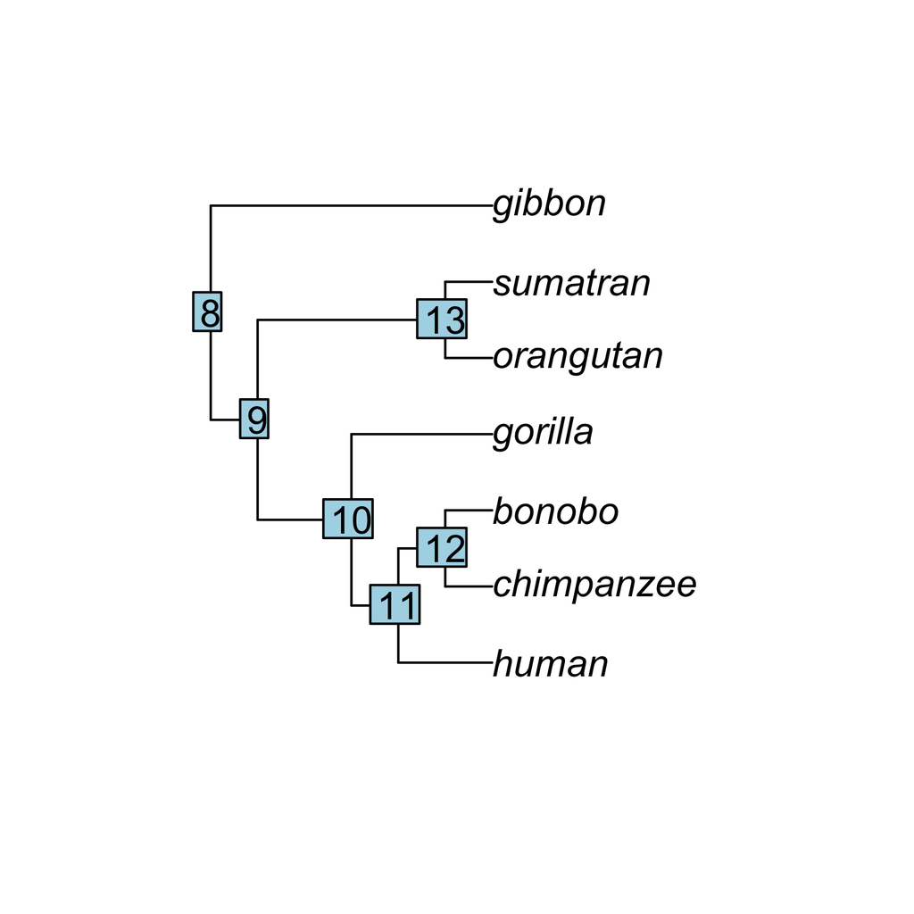

**Figure 1** Plot of the tree with node labelled with numbers

```r
plot(apeTree)
nodelabels()
```

```r
tipDes(apeTree, 10)
```

```
## [1] "gorilla"    "human"      "chimpanzee" "bonobo"
```

The calibrated nodes in this example are 8, 10, 11, and 13. The function `tipDes` takes the tree and node numbers as input and returns the taxon names that descend from that node; this output can be used directly in the functions below.

```r
monophyleticGroups.user <- tipDes(apeTree, c(8, 10, 11, 13))
monophyleticGroups.user
```

```
## $`8`
## [1] "gibbon"     "gorilla"    "orangutan"  "sumatran"   "human"
## [6] "chimpanzee" "bonobo"
##
## $`10`
## [1] "gorilla"    "human"      "chimpanzee" "bonobo"
##
## $`11`
## [1] "human"      "chimpanzee" "bonobo"
##
## $`13`
## [1] "orangutan" "sumatran"
```

# Estimate parameters for node input parameters

This section includes information to estimate and plot prior age distributions for node(s) used in MCMCtree divergence time estimation. The data required to do this are a phylogeny, minimum and maximum ages for the nodes with prior distributions, and taxa that descend from each node (please see above for information on how to make this various objects).

The code can be used to simultaneously estimate the parameter values that reflect the *a priori* time information for nodes and write files ready for MCMCtree input. MCMCtreeR can produce output files with the same type of distributions used to summarise *a priori* time information for all nodes, or different distributions can be used to reflect uncertainty on different internal nodes.

For each function, if only a single value is provided for each parameter by the user, the function outputs warnings to indicate these values are recycled for each node.

## Skew *t*

### estimate scale with a given shape

The default arguments in the `estimateSkewT` assumes the user wants to estimate the scale of the distribution with a given shape value (the default shape value is 50). The function estimates the parameters with the user-supplied minimum and maximum ages for all nodes, and the monophyletic groups that define the nodes.The output `skewT_results$MCMCtree` shows the estimated parameters in the input ready for MCMCtree. Here the parameters for the Skew *t* distributions are the location (lower node age), scale, shape, and degrees of freedom.

```r
skewT_results <- estimateSkewT(minAge = minimumTimes, maxAge = maximumTimes,
    monoGroups = monophyleticGroups, phy = apeTree, plot = FALSE)
```

```
## [1] "warning - minProb parameter value recycled"
## [1] "warning - maxProb parameter value recycled"
## [1] "warning - estimateScale argument recycled"
## [1] "warning - estimateShape argument recycled"
## [1] "warning - estimateMode argument recycled"
## [1] "warning - shape parameter value recycled"
## [1] "warning - addMode parameter value recycled"
```

```r
skewT_results$MCMCtree
```

```
##
## 1 7 1
##
## 1 ((((human,(chimpanzee,bonobo))'ST(0.8,0.016,50,1)',gorilla)'ST(0.6,0.024,50,1)',(orangutan,sumatran)'ST(1.3,0.028,50,1)'),gibbon)'ST(1.5,0.059,50,1)';
##
## 1 //end of file
```

As explained above, if only a single value is provided for each parameter by the user, the function outputs warnings to indicate these values are recycled for each node.

The function `plotMCMCtree` plots the estimated age distributions given these parameters.

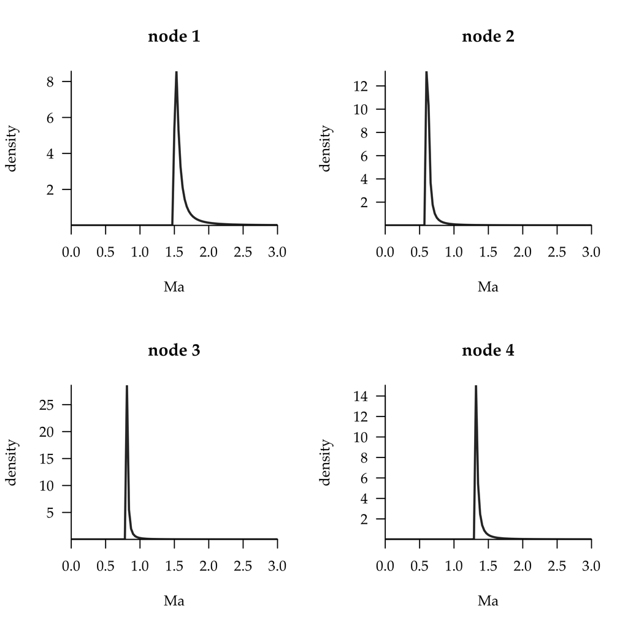

**Figure 2** Skew *t* distributions for all nodes

```r
par(mfrow = c(2, 2), family = "Palatino")
for (i in 1:4) plotMCMCtree(skewT_results$parameters[i, ], method = "skewT",
    title = paste0("node ", i), upperTime = max(maximumTimes))
```

```r
skewT_results$MCMCtree
```

```
##
## 1 7 1
##
## 1 ((((human,(chimpanzee,bonobo))'ST(0.8,0.016,50,1)',gorilla)'ST(0.6,0.024,50,1)',(orangutan,sumatran)'ST(1.3,0.028,50,1)'),gibbon)'ST(1.5,0.059,50,1)';
##
## 1 //end of file
```

If the distributions are acceptable, the output can be written into a tree file ready to be input into MCMCtree using the function `estimateSkewT`. The functions will be written when the argument `writeMCMCtree` is set to `TRUE`, and the file is set using the `MCMCtreeName` argument. Additionally, a PDF file is output showing the estimated distributions if `plot=TRUE` and the file name can be specifying using the argument `pdfOutput`.

```r
# result in tree MCMCtree format
skewT_results$MCMCtree
```

```
##
## 1 7 1
##
## 1 ((((human,(chimpanzee,bonobo))'ST(0.8,0.016,50,1)',gorilla)'ST(0.6,0.024,50,1)',(orangutan,sumatran)'ST(1.3,0.028,50,1)'),gibbon)'ST(1.5,0.059,50,1)';
##
## 1 //end of file
```

```r
## not run skewT_results <- estimateSkewT(minAge=minimumTimes,
## maxAge=maximumTimes, monoGroups=monophyleticGroups,
## phy=apeTree, plot=FALSE, pdfOutput='skewTPlot.pdf',
## writeMCMCtree=TRUE, MCMCtreeName='skewTInput.tre')
```

It is not necessary to specify the same shape value for each parameter: a different value of the shape parameter can be set for each distribution.

```r
## not run (remove ## to run) skewT_results <-
## estimateSkewT(minAge=minimumTimes, maxAge=maximumTimes,
## monoGroups=monophyleticGroups, shape=c(9, 10, 8, 10),
## phy=apeTree, plot=TRUE, pdfOutput='skewTPlot.pdf',
## writeMCMCtree=TRUE, MCMCtreeName='skewTInput.tre')
## skewT_results$parameters
```

### estimate shape with a given scale

The function `estimateSkewT` will take input minimum input times, and estimate the value of the shape that will produce the desired distribution with the scale parameter set to 0.05.

```r
skewT_results <- estimateSkewT(minAge = minimumTimes[2], maxAge = maximumTimes[2],
    monoGroups = monophyleticGroups, scale = 0.05, estimateShape = TRUE,
    estimateScale = FALSE, phy = apeTree, plot = FALSE, writeMCMCtree = FALSE)
skewT_results$parameters
```

```
##        location scale shape df
## node_1      0.6  0.05     1  1
```

## Skew normal

The `estimateSkewNormal` function estimates the value of the scale that will produce a skew normal distribution with the 97.5% cumulative probability of the distribution at the maximum age.

```r
skewNormal_results <- estimateSkewNormal(minAge = minimumTimes,
    maxAge = maximumTimes, monoGroups = monophyleticGroups, addMode = 0.05,
    phy = apeTree, plot = FALSE)
```

```
## [1] "warning - minProb parameter value recycled"
## [1] "warning - maxProb parameter value recycled"
## [1] "warning - estimateScale argument recycled"
## [1] "warning - estimateShape argument recycled"
## [1] "warning - estimateMode argument recycled"
## [1] "warning - shape parameter value recycled"
## [1] "warning - addMode parameter value recycled"
```

```r
skewNormal_results$parameters
```

```
##        location scale shape
## node_1     1.55  0.65    50
## node_2     0.65  0.25    50
## node_3     0.85  0.16    50
## node_4     1.35  0.29    50
```

These skew normal distributions can also be plotted to the screen.

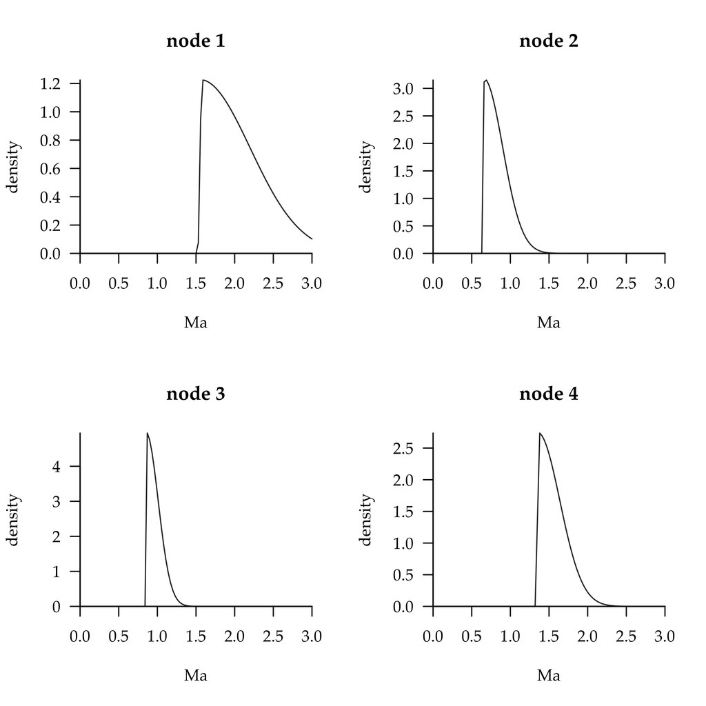

**Figure 3** Skew normal distributions for all nodes

```r
par(mfrow = c(2, 2), family = "Palatino")
for (i in 1:4) plotMCMCtree(skewNormal_results$parameters[i,
    ], method = "skewNormal", title = paste0("node ", i), upperTime = max(maximumTimes))
```

## Cauchy

Here the `estimateCauchy` function is used to estimate parameters and plot the example on page 49 of PAML manual.

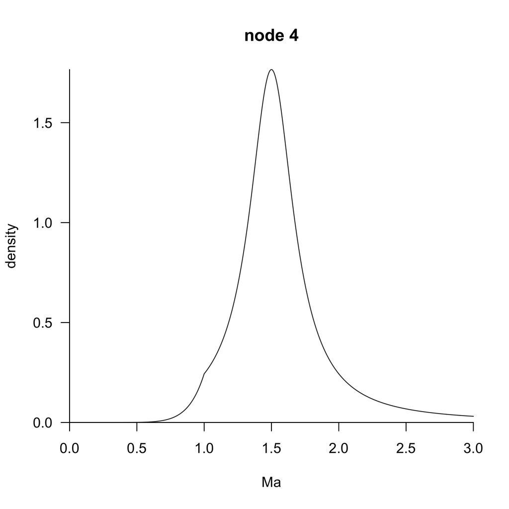

```r
example_page_50 <- estimateCauchy(minAge = 1, maxAge = 4.32,
    monoGroups = monophyleticGroups[[1]], phy = apeTree, offset = 0.5,
    minProb = 0.025, plot = FALSE)[[1]]
plotMCMCtree(example_page_50, method = "cauchy", title = paste0("node ",
    i), upperTime = max(maximumTimes))
```

### estimate scale with a given shape

The `estimateCauchy` function will take minimum input times, and estimate the value of the scale parameter that will produce a Cauchy distribution with the 97.5% cumulative probability of the distribution at the user-supplied maximum age.

```r
cauchy_results <- estimateCauchy(minAge = minimumTimes, maxAge = maximumTimes,
    monoGroups = monophyleticGroups, offset = 0.5, phy = apeTree,
    plot = FALSE)
```

```
## [1] "warning - minProb parameter value recycled"
## [1] "warning - maxProb parameter value recycled"
## [1] "warning - offset parameter value recycled"
## [1] "warning - scale parameter value recycled"
## [1] "warning - estimateScale argument recycled"
```

```r
cauchy_results$parameters
```

```
##         tL   p     c     pL
## node_1 1.5 0.5 0.075 1e-300
## node_2 0.6 0.5 0.008 1e-300
## node_3 0.8 0.5 0.001 1e-300
## node_4 1.3 0.5 0.016 1e-300
```

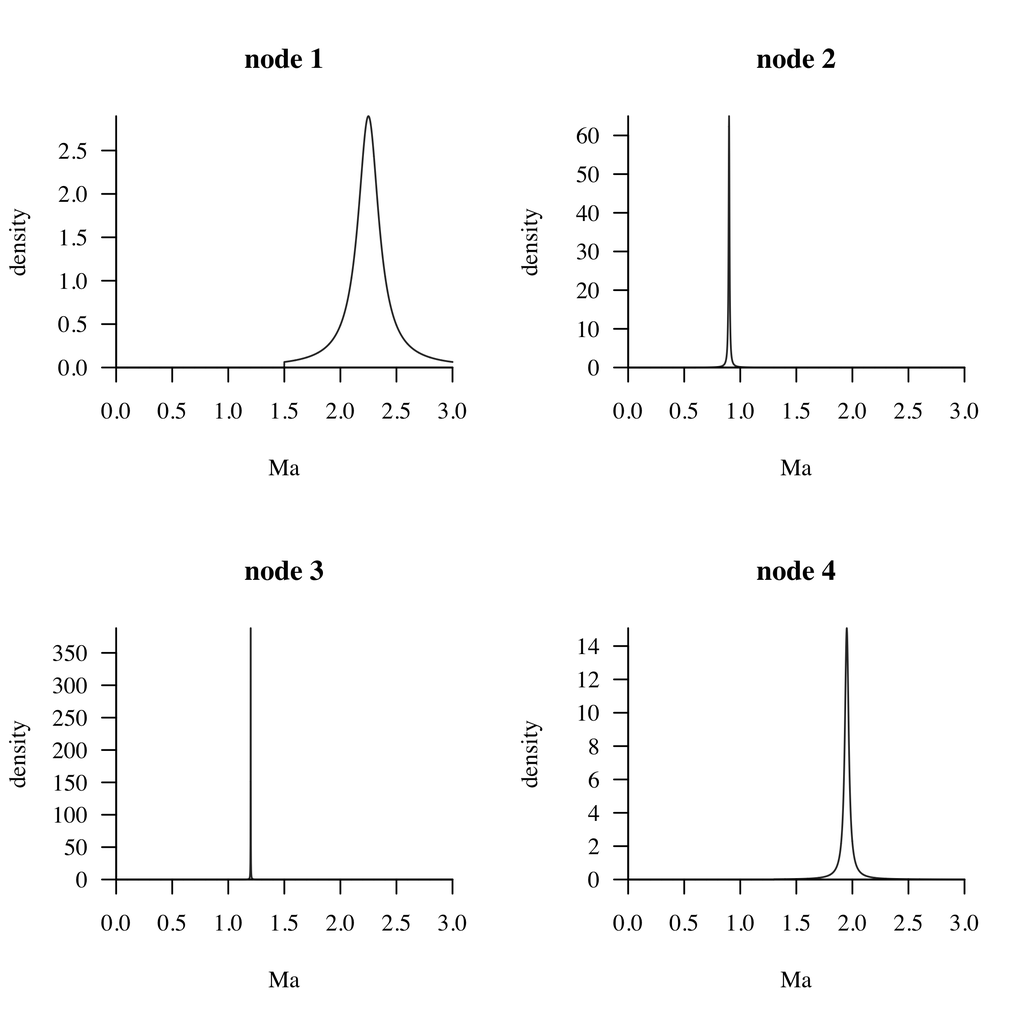

**Figure 5** Cauchy distributions for all nodes (with a given shape)

```r
par(mfrow = c(2, 2), family = "Times")
for (i in 1:4) plotMCMCtree(cauchy_results$parameters[i, ], method = "cauchy",
    title = paste0("node ", i), upperTime = max(maximumTimes))
```

These plots indicate we may have constrained our distribution too much for the 2nd, 3rd, and 4th distribution so we can modify that to allow for a smaller offset.

```r
cauchy_results <- estimateCauchy(minAge = minimumTimes, maxAge = maximumTimes,
    monoGroups = monophyleticGroups, offset = c(0.5, 0.1, 0.1,
        0.05), phy = apeTree, plot = FALSE)
```

```
## [1] "warning - minProb parameter value recycled"
## [1] "warning - maxProb parameter value recycled"
## [1] "warning - scale parameter value recycled"
## [1] "warning - estimateScale argument recycled"
```

```r
cauchy_results$parameters
```

```
##         tL    p     c     pL
## node_1 1.5 0.50 0.075 1e-300
## node_2 0.6 0.10 0.035 1e-300
## node_3 0.8 0.10 0.022 1e-300
## node_4 1.3 0.05 0.040 1e-300
```

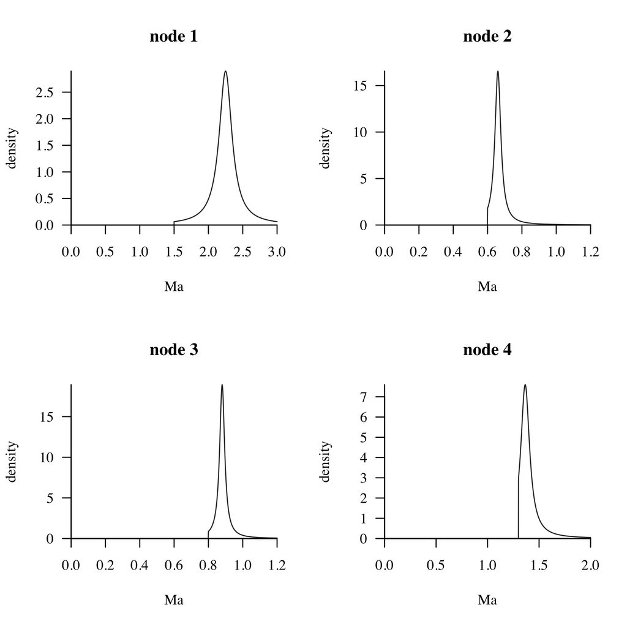

**Figure 6** Cauchy distributions for all nodes (with a given shape) and smaller offset

```r
par(mfrow = c(2, 2), family = "Times")
for (i in 1:4) plotMCMCtree(cauchy_results$parameters[i, ], method = "cauchy",
    title = paste0("node ", i), upperTime = maximumTimes[i])
```

## Uniform distribution

```r
uniform_results <- estimateBound(minAge = minimumTimes, maxAge = maximumTimes,
    monoGroups = monophyleticGroups, phy = apeTree, plot = FALSE)
```

```
## [1] "warning - minProb parameter value recycled"
## [1] "warning - maxProb parameter value recycled"
```

```r
uniform_results$parameters
```

```
##         tL  tU    pL    pU
## node_1 1.5 3.0 0.025 0.025
## node_2 0.6 1.2 0.025 0.025
## node_3 0.8 1.2 0.025 0.025
## node_4 1.3 2.0 0.025 0.025
```

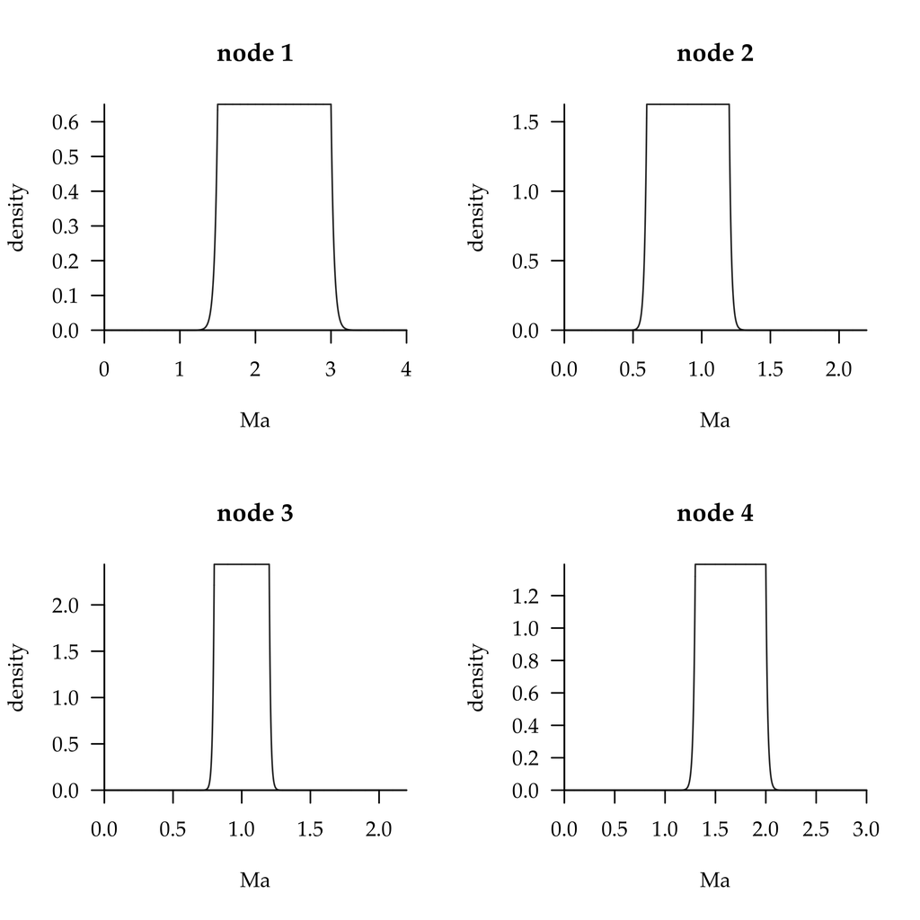

**Figure 7** Uniform distributions for all nodes

```r
par(mfrow = c(2, 2), family = "Palatino")
for (i in 1:4) plotMCMCtree(uniform_results$parameters[i, ],
    method = "bound", title = paste0("node ", i), upperTime = maximumTimes[i] +
        1)
```

## Gamma distribution

```r
gamma_results <- estimateGamma(minAge = minimumTimes, maxAge = maximumTimes,
    monoGroups = monophyleticGroups, alpha = 188, beta = 2690,
    offset = 0.1, phy = apeTree, plot = FALSE)
```

```
## [1] "warning - alpha parameter value recycled"
## [1] "warning - beta parameter value recycled"
## [1] "warning - offset parameter value recycled"
## [1] "warning - estimateAlpha argument recycled"
## [1] "warning - estimateBeta argument recycled"
```

```r
gamma_results$parameters
```

```
##        alpha beta
## node_1  4304 2690
## node_2  1883 2690
## node_3  2421 2690
## node_4  3766 2690
```

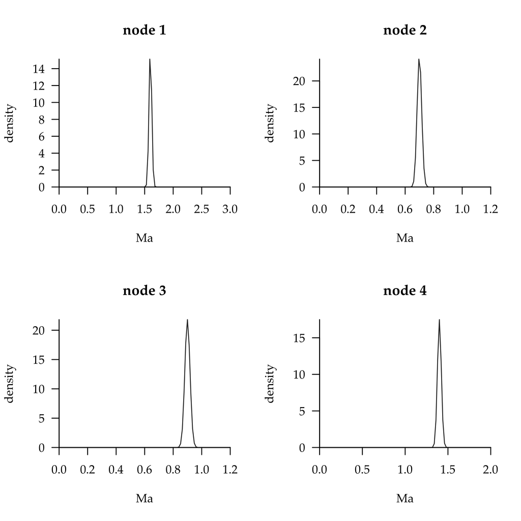

**Figure 8** Gamma distributions for all nodes

```r
par(mfrow = c(2, 2), family = "Palatino")
for (i in 1:4) plotMCMCtree(gamma_results$parameters[i, ], method = "gamma",
    title = paste0("node ", i), upperTime = maximumTimes[i])
```

## Upper Age

```r
upper_results <- estimateUpper(maxAge = maximumTimes, monoGroups = monophyleticGroups,
    rightTail = 0.025, phy = apeTree)
```

```
## [1] "warning - maxProb parameter value recycled"
```

```r
upper_results$parameters
```

```
##         tU    pR
## node_1 3.0 0.025
## node_2 1.2 0.025
## node_3 1.2 0.025
## node_4 2.0 0.025
```

## Fixed ages

```r
fixed_results <- estimateFixed(minAge = minimumTimes[1], monoGroups = monophyleticGroups[[1]],
    phy = apeTree)
fixed_results
```

```
## $parameters
## fixed age.nodeOne
##               1.5
##
## $apePhy
##
## Phylogenetic tree with 7 tips and 6 internal nodes.
##
## Tip labels:
##  human, chimpanzee, bonobo, gorilla, orangutan, sumatran, ...
## Node labels:
## [1] "'=1.5'"
##
## Rooted; no branch lengths.
##
## $MCMCtree
##
## 1 7 1
##
## 1 ((((human,(chimpanzee,bonobo)),gorilla),(orangutan,sumatran)),gibbon)'=1.5';
##
## 1 //end of file
##
## $nodeLabels
## [1] "'=1.5'"
```

## Different parameters on different nodes

```r
each.node.method <- c("skewT", "cauchy", "gamma", "upper")
output.full <- MCMCtreePhy(phy = apeTree, minAge = minimumTimes,
    maxAge = maximumTimes, monoGroups = monophyleticGroups, method = each.node.method,
    writeMCMCtree = FALSE)
```

This can fine-tuned. For example, to estimate alpha not beta for the 3rd node

```r
estimate.alpha <- c(FALSE, FALSE, TRUE, FALSE)
estimate.beta <- c(TRUE, TRUE, FALSE, TRUE)
outputFull <- MCMCtreePhy(phy = apeTree, minAges = minimumTimes,
    maxAges = maximumTimes, monoGroups = monophyleticGroups,
    method = each.node.method, estimateAlpha = estimate.alpha,
    estimateBeta = estimate.beta, alpha = 188, beta = 100, writeMCMCtree = FALSE)
```

Outputs from individual methods can be added to the input for subsequent node estimation. This allows for easier fine-tuning. Perhaps easier to explain with an example. Here, a skew normal calibration is applied to the first node.

```r
skewNormal_results_nodeOne <- estimateSkewNormal(minAge = minimumTimes[1],
    maxAge = maximumTimes[1], monoGroups = monophyleticGroups[[1]],
    addMode = 0.05, phy = apeTree, plot = FALSE, writeMCMCtree = FALSE)
skewNormal_results_nodeOne$apePhy
```

```
##
## Phylogenetic tree with 7 tips and 6 internal nodes.
##
## Tip labels:
##  human, chimpanzee, bonobo, gorilla, orangutan, sumatran, ...
## Node labels:
## [1] "'SN[1.55~0.65~50]'"
##
## Rooted; no branch lengths.
```

This output is then used as input in `estimateCauchy` to estimate parameters for a Cauchy distribution, which is applied to the second node.

```r
cauchy_results_nodeTwo <- estimateCauchy(minAge = minimumTimes[2],
    maxAge = maximumTimes[2], monoGroups = monophyleticGroups[[2]],
    offset = 0.5, phy = skewNormal_results_nodeOne$apePhy, plot = FALSE,
    writeMCMCtree = FALSE)
cauchy_results_nodeTwo$apePhy
```

```
##
## Phylogenetic tree with 7 tips and 6 internal nodes.
##
## Tip labels:
##  human, chimpanzee, bonobo, gorilla, orangutan, sumatran, ...
## Node labels:
## [1] "'SN[1.55~0.65~50]'"        NA
## [3] "'L[0.6~0.5~0.008~1e-300]'"
##
## Rooted; no branch lengths.
```

The third node is the set as a uniform distribution.

```r
uniform_results_nodeThree <- estimateBound(minAge = minimumTimes[3],
    maxAge = maximumTimes[3], monoGroups = monophyleticGroups[[3]],
    phy = cauchy_results_nodeTwo$apePhy, plot = FALSE, writeMCMCtree = FALSE)
uniform_results_nodeThree$apePhy
```

```
##
## Phylogenetic tree with 7 tips and 6 internal nodes.
##
## Tip labels:
##  human, chimpanzee, bonobo, gorilla, orangutan, sumatran, ...
## Node labels:
## [1] "'SN[1.55~0.65~50]'"        NA
## [3] "'L[0.6~0.5~0.008~1e-300]'" "'B[0.8~1.2~0.025~0.025]'"
##
## Rooted; no branch lengths.
```

The fourth is a skewT distribution, and the tree can be written to file for input into MCMCtree.

```r
## not run skewT_results_nodeFour <-
## estimateSkewT(minAge=minimumTimes[4],
## maxAge=maximumTimes[4], monoGroups=monophyleticGroups[[4]],
## scale=0.5, phy=cauchy_results_nodeTwo$apePhy, plot=FALSE,
## writeMCMCtree = TRUE) skewT_results_nodeFour$apePhy
```